# Storm Events Affect Constituent Lives

Scott Roberts

April 30, 2016

## Synopsis:

The purpose of this analysis is to determine the impact of storm events on people’s lives and the larger economy. Perhaps with this knowledge, federal,state and local governments can allocate resources to those areas to early warning detections of the most harmful storm events. As far as the economy, those government entities can set aside on money for economic damage yearly to mitigate farm and property damage. What we found was, based on storm data dating back to 1950, Tornados caused the most harm to population health with 96,979 combined Injuries and Fatalities. As for economic impacts, Tornadoes coupled with Hail cause the most damage of 1.6 billion dollars. Although these damage estimates are broad they are still significant.

## Data Processing

First, we retrieved the data from the website, and extract it to a csv file. In order to process and transform the data we create a data frame from the csv file.

```r
library(ggplot2)
library(dplyr)
library(tidyr)

#Obtain the data from the source website
furl <- "https://d396qusza40orc.cloudfront.net/repdata%2Fdata%2FStormData.csv.bz2"
download.file(furl, destfile= "repdatadataStormData.csv.bz2", method="curl")
#Create the data frame
stormy <- read.csv("repdatadataStormData.csv.bz2")
stormydf <- tbl_df(stormy)
##Convert the dollar amounts to millions for property and farm damage

##Property Damage Conversion
stormydf$PROPDMGcv[stormydf$PROPDMGEXP == "B"] <- stormydf$PROPDMG[stormydf$PROPDMGEXP == "B"]*1000
stormydf$PROPDMGcv[stormydf$PROPDMGEXP == "K"] <- stormydf$PROPDMG[stormydf$PROPDMGEXP == "K"]/1000
stormydf$PROPDMGcv[stormydf$PROPDMGEXP == "H"] <- stormydf$PROPDMG[stormydf$PROPDMGEXP == "H"]/10000

stormydf$PROPDMGcv[stormydf$PROPDMGEXP == "M"] <- stormydf$PROPDMG[stormydf$PROPDMGEXP == "M"]


#Crop Damage Conversion
stormydf$CROPDMGcv[stormydf$CROPDMGEXP == "B"] <- stormydf$CROPDMG[stormydf$CROPDMGEXP == "B"]*1000
stormydf$CROPDMGcv[stormydf$CROPDMGEXP == "K"] <- stormydf$CROPDMG[stormydf$CROPDMGEXP == "K"]/1000
stormydf$CROPDMGcv[stormydf$CROPDMGEXP == "H"] <- stormydf$CROPDMG[stormydf$CROPDMGEXP == "H"]/10000
stormydf$CROPDMGcv[stormydf$CROPDMGEXP == "M"] <- stormydf$CROPDMG[stormydf$CROPDMGEXP == "M"]

stormgrp <- group_by(stormydf, EVTYPE)
```

From there, we can begin the Analysis.

# Harm Caused by Storms

After summarizing the data, and taking the top 5 events that cause harm. So we take the columns Injuries and Fatailities and make the Summary table.

```r
stormgrp1 <- summarize(stormgrp, FatalNum = sum(FATALITIES), Injuries=sum(INJURIES), All = Injuries+FatalNum)
arrange(stormgrp1, desc(FatalNum))
```

```
## Source: local data frame [985 x 4]
##
##            EVTYPE FatalNum Injuries   All
##            (fctr)    (dbl)    (dbl) (dbl)
## 1         TORNADO     5633    91346 96979
## 2  EXCESSIVE HEAT     1903     6525  8428
## 3     FLASH FLOOD      978     1777  2755
## 4            HEAT      937     2100  3037
## 5       LIGHTNING      816     5230  6046
## 6       TSTM WIND      504     6957  7461
## 7           FLOOD      470     6789  7259
## 8     RIP CURRENT      368      232   600
## 9       HIGH WIND      248     1137  1385
## 10      AVALANCHE      224      170   394
## ..            ...      ...      ...   ...
```

```r
ttl <- arrange(stormgrp1, desc(All, Injuries, FatalNum))[1:5,]
ttl
```

```
## Source: local data frame [5 x 4]
##
##           EVTYPE FatalNum Injuries   All
##           (fctr)    (dbl)    (dbl) (dbl)
## 1        TORNADO     5633    91346 96979
## 2 EXCESSIVE HEAT     1903     6525  8428
## 3      TSTM WIND      504     6957  7461
## 4          FLOOD      470     6789  7259
## 5      LIGHTNING      816     5230  6046
```

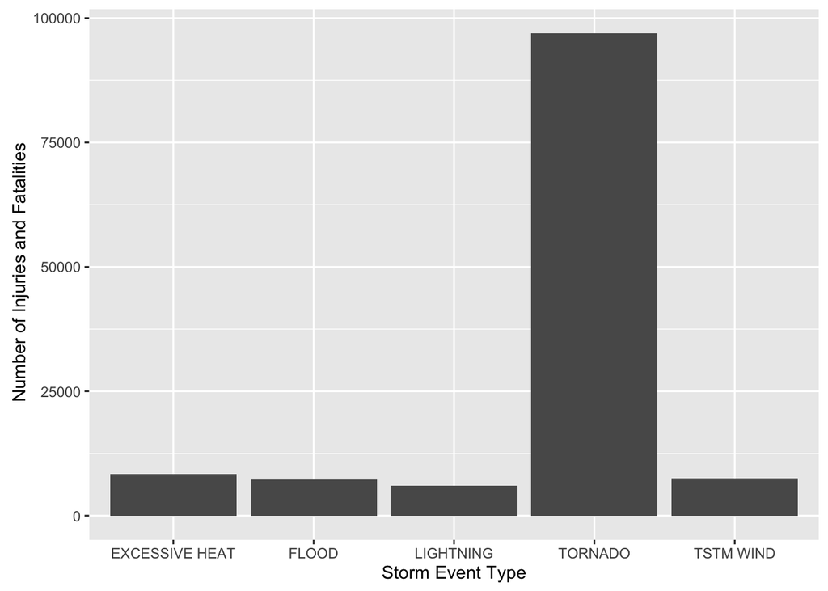

```r
qplot(EVTYPE, data=ttl, geom="bar", weight=All, ylab=" Number of Injuries and Fatalities", xlab="Storm Event Type")
```

Economic Impacts of Storm Events

Calculate the Economic damagegiven by the Property Damage and Crop Damage columns. First to get the actual dollar amount the Property Damage dollar factor multiply by a factor 1,000 or 1 million.

```r
stormfiscal <- summarize(stormgrp, Property = sum(PROPDMGcv), Crop=sum(CROPDMGcv), Both=Property+Crop)
econimpact <- arrange(stormfiscal, desc(Both))[1:5,]
econimpact
```

```
## Source: local data frame [5 x 4]
##
##                       EVTYPE Property  Crop   Both
##                       (fctr)    (dbl) (dbl)  (dbl)
## 1 TORNADOES, TSTM WIND, HAIL   1600.0   2.5 1602.5
## 2            HIGH WINDS/COLD    110.5   7.0  117.5
## 3  HURRICANE OPAL/HIGH WINDS    100.0  10.0  110.0
## 4    WINTER STORM HIGH WINDS     60.0   5.0   65.0
## 5       Heavy Rain/High Surf     13.5   1.5   15.0
```

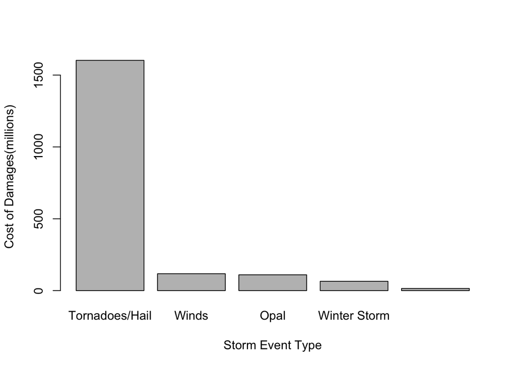

```r
barplot(econimpact$Both,names.arg= c("Tornadoes/Hail","Winds","Opal","Winter Storm","Heavy Rain/Surf"), xlab="Storm Event Type", ylab="Cost of Damages(millions)" )
```

```r
#qplot(EVTYPE, data=econimpact, geom="bar", weight=Both, ylab="Cost of Damages(millions)", xlab="Storm Event Type")
```

## Conclusions

The results clearly point out that Tornadoes with Hail cause the most damage, and Tornadoes cause the most physical harm.